# Working with range data

#### Working on multiple ranges

```r
# 1. Reduce
set.seed(0) # this sets the seed for the pseudo-random number generator
alns <- IRanges(start = sample(seq_len(50),20), width = 5)
# seq_len(50) = 1:50
# sample(seq_len(50), 20) randomly samples 20 values from 1:50 without replacement
head(alns, 4)
```

```
## IRanges object with 4 ranges and 0 metadata columns:
##           start       end     width
##       <integer> <integer> <integer>
##   [1]        14        18         5
##   [2]         4         8         5
##   [3]        39        43         5
##   [4]         1         5         5
```

```r
reduce(alns) # reduce takes a set of possibly overlapping ranges and reduces them to a set of nonoverlapping ranges
```

```
## IRanges object with 2 ranges and 0 metadata columns:
##           start       end     width
##       <integer> <integer> <integer>
##   [1]         1        29        29
##   [2]        33        54        22
```

```r
# 4. Gaps
gaps(alns) #find the gap between the ranges
```

```
## IRanges object with 1 range and 0 metadata columns:
##           start       end     width
##       <integer> <integer> <integer>
##   [1]        30        32         3
```

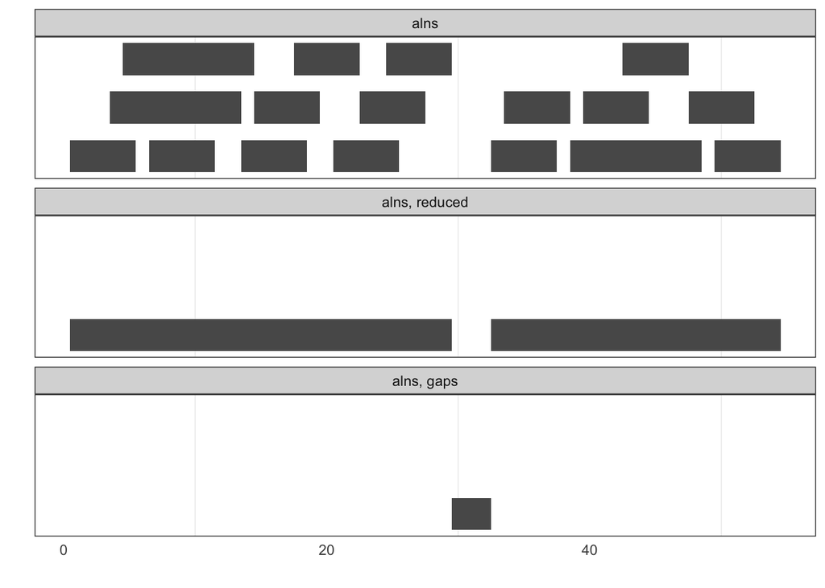

```r
plotIRanges(alns=alns, "alns, reduced"=reduce(alns), "alns, gaps"=gaps(alns), set_breaks = FALSE)
```

#### Set operations

Difference, intersection, union

```r
a <- IRanges(start=4, end=13)
b <- IRanges(start=12, end=17)
intersect(a, b)
```

```
## IRanges object with 1 range and 0 metadata columns:
##           start       end     width
##       <integer> <integer> <integer>
##   [1]        12        13         2
```

```r
setdiff(a, b)
```

```
## IRanges object with 1 range and 0 metadata columns:
##           start       end     width
##       <integer> <integer> <integer>
##   [1]         4        11         8
```

```r
setdiff(b, a)
```

```
## IRanges object with 1 range and 0 metadata columns:
##           start       end     width
##       <integer> <integer> <integer>
##   [1]        14        17         4
```

```r
union(b, a)
```

```
## IRanges object with 1 range and 0 metadata columns:
##           start       end     width
##       <integer> <integer> <integer>
##   [1]         4        17        14
```

```r
union(a, b)
```

```
## IRanges object with 1 range and 0 metadata columns:
##           start       end     width
##       <integer> <integer> <integer>
##   [1]         4        17        14
```

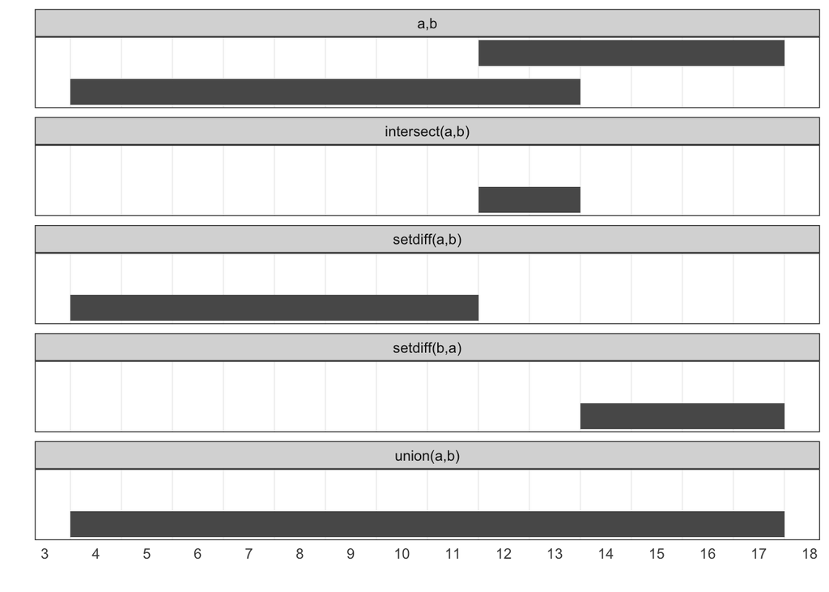

```r
plotIRanges("a,b"=c(a,b), "intersect(a,b)"=intersect(a, b), "setdiff(a,b)"=setdiff(a, b), "setdiff(b,a)"=setdiff(b,a), "union(a,b)"=union(b, a))
```

### FindOverlaps

Finding overlaps is a very common operation required in genomics, such as counting reads based on gene annotations. It is seemingly simple but in reality quite complicated, not because of the computation being hard, but because of the intricacy of defining “overlap”. Here we will learn the basics of finding overlaps. Later we will learn more specific operations on genomic ranges

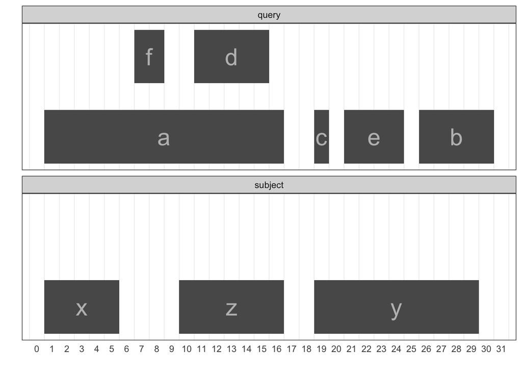

```r
# this operation is direction, that is we start with a "query" and look for overlaps in a "subject"
qry<- IRanges(start = c(1, 26, 19, 11, 21, 7), end = c(16, 30, 19, 15, 24, 8), names = letters[1:6])
sbj<- IRanges(start=c(1, 19, 10), end=c(5, 29, 16), names = letters[24:26])
plotIRanges(query=qry,subject=sbj)
```

```r
hts<- findOverlaps(qry, sbj) # find the overlap between the qry and sbj
hts
```

```
## Hits object with 6 hits and 0 metadata columns:
##       queryHits subjectHits
##       <integer>   <integer>
##   [1]         1           1
##   [2]         1           3
##   [3]         2           2
##   [4]         3           2
##   [5]         4           3
##   [6]         5           2
##   -------
##   queryLength: 6 / subjectLength: 3
```

```r
names(qry)[queryHits(hts)]
```

```
## [1] "a" "a" "b" "c" "d" "e"
```

```r
names(sbj)[subjectHits(hts)] # find the name of each query and subject range with an overlap
```

```
## [1] "x" "z" "y" "y" "z" "y"
```

```r
hts_within<- findOverlaps(qry, sbj, type = "within") # limit our overlap results to only include query ranges that fall entirely within subject ranges
hts_within
```

```
## Hits object with 3 hits and 0 metadata columns:
##       queryHits subjectHits
##       <integer>   <integer>
##   [1]         3           2
##   [2]         4           3
##   [3]         5           2
##   -------
##   queryLength: 6 / subjectLength: 3
```

```r
findOverlaps(qry, sbj, select = "first")
```

```
## [1]  1  2  2  3  2 NA
```

```r
findOverlaps(qry, sbj, select = "last")
```

```
## [1]  3  2  2  3  2 NA
```

```r
findOverlaps(qry, sbj, select = "arbitrary")
```

```
## [1]  1  2  2  3  2 NA
```

```r
# accessor functions for the internal components of a "hit" object
as.matrix(hts) # Hits objects can be coerced to matrix
```

```
##      queryHits subjectHits
## [1,]         1           1
## [2,]         1           3
## [3,]         2           2
## [4,]         3           2
## [5,]         4           3
## [6,]         5           2
```

```r
countQueryHits(hts) # How many subject ranges each query IRanges object overlaps
```

```
## [1] 2 1 1 1 1 0
```

```r
setNames(countQueryHits(hts), names(qry))
```

```
## a b c d e f
## 2 1 1 1 1 0
```

```r
countSubjectHits(hts) # How many query ranges overlap the subject ranges
```

```
## [1] 1 3 2
```

```r
setNames(countSubjectHits(hts), names(sbj))
```

```
## x y z
## 1 3 2
```

```r
# SubsetByOverlaps and countOverlaps
countOverlaps(qry, sbj) # countoverlaps is similar to the soultion using countQueryOverlaps and setnames
```

```
## a b c d e f
## 2 1 1 1 1 0
```

```r
subsetByOverlaps(qry, sbj) #it is same as qry[unique(queryHits(hts))]
```

```
## IRanges object with 5 ranges and 0 metadata columns:
##         start       end     width
##     <integer> <integer> <integer>
##   a         1        16        16
##   b        26        30         5
##   c        19        19         1
##   d        11        15         5
##   e        21        24         4
```

### Finding Nearest Ranges and Calculating Distance

This is another common operations on ranges, namely finding the nearest ranges and calculating distance from it. Imagine that you have experimentally determined the locations in the genome bound by some important regulatory proteins. Not knowing which gene these proteins regulate, you best guess is that they regulate the gene that is the closest to the protein (often not a bad assumption to start with). Thus your tasks is, given two set of ranges – the first for the places where the protein binds and the second the “address” for every gene in the genome – to find the nearest gene to each binding site. Here we will learn how to do this with the abstraction of IRanges

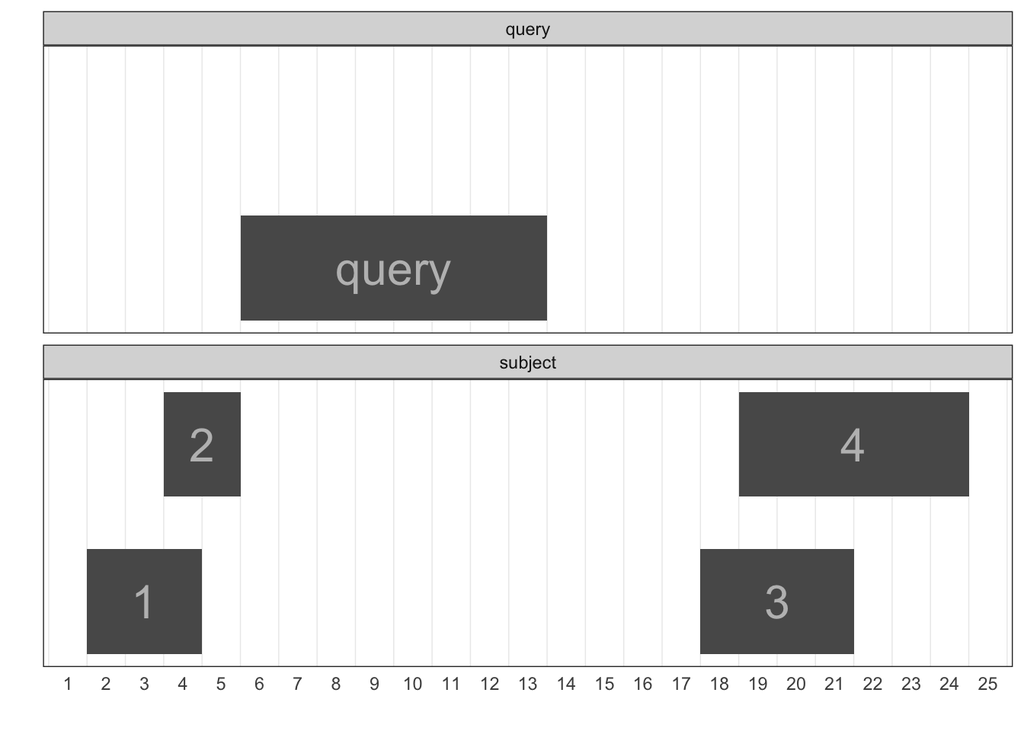

```r
qry<- IRanges(start=6, end = 13, names = 'query')
sbj<- IRanges(start = c(2, 4, 18, 19), end = c(4, 5, 21, 24), names = 1:4)
plotIRanges(query=qry, subject=sbj)
```

```r
nearest(qry, sbj) # return the nearest range, regardless of whether it's upsteam or downstream of the query
```

```
## [1] 2
```

```r
precede(qry, sbj) # return the nearest range that the query is upstream
```

```
## [1] 3
```

```r
follow(qry, sbj) # return the nearest range that the query is downstream
```

```
## [1] 2
```

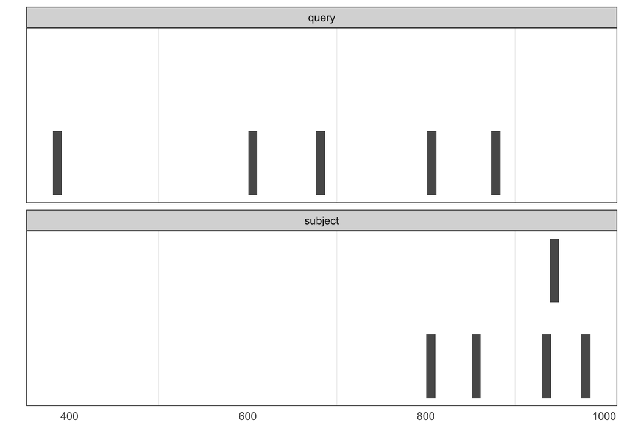

```r
# Distance to Nearest
qry<- IRanges(sample(seq_len(1000), 5), width = 10)
sbj<- IRanges(sample(seq_len(1000), 5), width = 10)
plotIRanges(query=qry, subject=sbj, set_breaks = FALSE)
```

```r
distanceToNearest(qry, sbj) # It finds the closest subject range, and returns everything in a Hits object with an additional column indicating the distance
```

```
## Hits object with 5 hits and 1 metadata column:
##       queryHits subjectHits |  distance
##       <integer>   <integer> | <integer>
##   [1]         1           3 |       114
##   [2]         2           3 |         0
##   [3]         3           4 |        12
##   [4]         4           3 |       409
##   [5]         5           3 |       190
##   -------
##   queryLength: 5 / subjectLength: 5
```

```r
distance(qry, sbj) # returns each pairwise distance between query and subject ranges
```

```
## [1] 253 163  63 460 320
```

### Calculating coverages

A common task in genomics analyses is to calculate the coverage, that is, for each position in a genome, how many reads map to that position or range. For example, one may encounter this while sequencing a new genome. Because of the sequencing errors, one usually try to cover each position in that genome with multiple reads, so that sequencing errors can be identified and removed by spotting inconsistence between a subset of the reads at a particular position with the majority of the reads at that position.

Calculating coverage can be thought of as a special instance of counting overlaps – when the subject ranges are precisely length of 1 and tiles across the genome (challenge: what would be the mode of counting overlaps in the application to coverage calculation?).

What’s special about calculating coverages compared with the type of counting overlaps we just discussed is the data density – the list of subject ranges is exactly as large as the number of nucleotides (or any other sequences) as the genome (or proteome, etc.). This raises a practical problem: to represent that many ranges and doing calculation over all of them becomes computationally expensive, especially for memory. To solve this problem, researchers have come up with a clever way of encoding coverage data, which is termed run length encoding. We will see what Run Length Encoding is and how it is used in calculating coverages.

#### Run Length Encoding and Views

```r
x <- as.integer(c(4, 4, 4, 3, 3, 2, 1, 1, 1, 1, 1, 0, 0, 0, 0, 0, 0, 0, 1, 1, 1, 4, 4, 4, 4, 4, 4, 4))
sprintf("The length of the vector x is %i", length(x))
```

```
## [1] "The length of the vector x is 28"
```

```r
xrle <- Rle(x) # Run-length encoding compresses this sequence
xrle          # note that instead of
```

```
## integer-Rle of length 28 with 7 runs
##   Lengths: 3 2 1 5 7 3 7
##   Values : 4 3 2 1 0 1 4
```

```r
sprintf("The length of the run length object xrle is %i", length(runValue(xrle)))
```

```
## [1] "The length of the run length object xrle is 7"
```

```r
# however, in reality the run length object not only store the values and length of each "run", but also other accessory information, making them bigger than the original object when the latter is a small vector. This is often termed memory overheads. What this menas is that Rle is not efficient unless the original vector is rather big.
str(xrle)
```

```
## Formal class 'Rle' [package "S4Vectors"] with 4 slots
##   ..@ values         : int [1:7] 4 3 2 1 0 1 4
##   ..@ lengths        : int [1:7] 3 2 1 5 7 3 7
##   ..@ elementMetadata: NULL
##   ..@ metadata       : list()
```

```r
# Let's comapre the memory used by the original and Rle encoded objects.
sprintf("The size of the vector x is %i bytes", object.size(x))
```

```
## [1] "The size of the vector x is 176 bytes"
```

```r
sprintf("The size of the Rle object xrle is %i bytes", object.size(xrle))
```

```
## [1] "The size of the Rle object xrle is 1224 bytes"
```

```r
as.vector(xrle) # revert back to vector
```

```
##  [1] 4 4 4 3 3 2 1 1 1 1 1 0 0 0 0 0 0 0 1 1 1 4 4 4 4 4 4 4
```

#### (Optional) Basic operations of Run-length encoding

```r
xrle + 4L
```

```
## integer-Rle of length 28 with 7 runs
##   Lengths: 3 2 1 5 7 3 7
##   Values : 8 7 6 5 4 5 8
```

```r
xrle  /2
```

```
## numeric-Rle of length 28 with 7 runs
##   Lengths:   3   2   1   5   7   3   7
##   Values :   2 1.5   1 0.5   0 0.5   2
```

```r
xrle > 3
```

```
## logical-Rle of length 28 with 3 runs
##   Lengths:     3    18     7
##   Values :  TRUE FALSE  TRUE
```

```r
xrle[xrle > 3]
```

```
## integer-Rle of length 10 with 1 run
##   Lengths: 10
##   Values :  4
```

```r
sum(xrle)
```

```
## [1] 56
```

```r
summary(xrle)
```

```
##    Min. 1st Qu.  Median    Mean 3rd Qu.    Max.
##    0.00    0.75    1.00    2.00    4.00    4.00
```

```r
round(cos(xrle), 2)
```

```
## numeric-Rle of length 28 with 7 runs
##   Lengths:     3     2     1     5     7     3     7
##   Values : -0.65 -0.99 -0.42  0.54     1  0.54 -0.65
```

```r
runLength(xrle) # Rle object's lengths
```

```
## [1] 3 2 1 5 7 3 7
```

```r
runValue(xrle) # Rle object's values
```

```
## [1] 4 3 2 1 0 1 4
```

#### Coverage(where we encounter Rle)

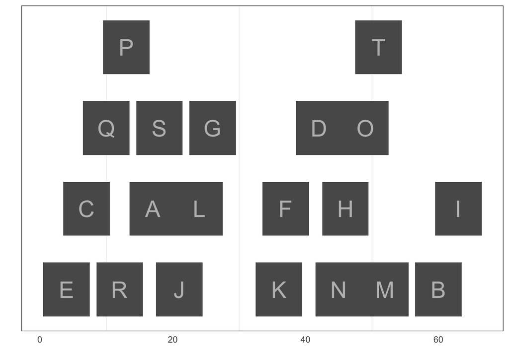

```r
set.seed(0)
rngs <- IRanges(start = sample(seq_len(60), 20), width=7)
names(rngs) <- LETTERS[1:20] # label one range for examples later
plotIRanges(rngs, set_breaks = FALSE)
```

```r
rngs_cov <- coverage(rngs)
rngs_cov[rngs['A']] # what the coverage was in the region overlapping the range laberled "A"
```

```
## integer-Rle of length 7 with 5 runs
##   Lengths: 1 1 1 1 3
##   Values : 3 4 3 2 3
```

```r
mean(rngs_cov[rngs["A"]]) # find the mean coverage within this range
```

```
## [1] 3
```

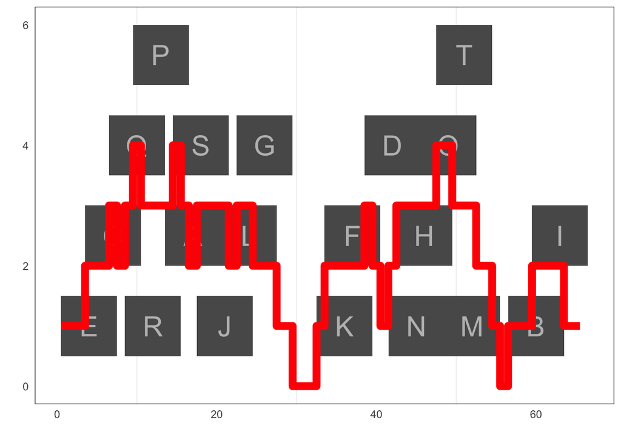

```r
plotIRanges(rngs, cov = TRUE, set_breaks = FALSE)
```

```r
rngs_cov > 3 # where is coverage greater than 3
```

```
## logical-Rle of length 66 with 7 runs
##   Lengths:     9     1     4     1    32     2    17
##   Values : FALSE  TRUE FALSE  TRUE FALSE  TRUE FALSE
```

```r
rngs_cov[as.vector(rngs_cov)>3] # extract the depths that are greater than 3
```

```
## integer-Rle of length 4 with 1 run
##   Lengths: 4
##   Values : 4
```

#### (Optional) Going from run-length encoded sequences to ranges with slice()

Sometimes you want to create ranges based on the coverage data. For example, after mapping your reads to the reference genome, you would like to identify all regions covered by at least two reads, or, conversely, you want to find out all regions with less than two reads, which you may consider leaving out of your analysis. You can do this with the `slice()` function, which operates on an Rle object.

```r
min_cov2 <- slice(rngs_cov, lower=2) # take our coverage Rle object rngs_cov and slice it to create ranges corresponding to regions with more than 2x coverage
min_cov2
```

```
## Views on a 66-length Rle subject
##
## views:
##     start end width
## [1]     4  27    24 [2 2 2 3 2 3 4 3 3 3 3 4 3 2 3 3 3 3 2 3 3 2 2 2]
## [2]    34  40     7 [2 2 2 2 2 3 2]
## [3]    42  54    13 [2 3 3 3 3 3 4 4 3 3 3 2 2]
## [4]    60  63     4 [2 2 2 2]
```

#### (Optional) Advanced IRanges:Views

```r
viewMeans(min_cov2) # find the mean
```

```
## [1] 2.708333 2.142857 2.923077 2.000000
```

```r
viewMaxs(min_cov2) # find the Maximum
```

```
## [1] 4 3 4 2
```

```r
viewApply(min_cov2, median) # find the median
```

```
## [1] 3 2 3 2
```

```r
length(rngs_cov)
```

```
## [1] 66
```

```r
bwidth <- 5L # we will set bwidth to be our bin width
end <- bwidth * floor(length(rngs_cov)/ bwidth) # we compute the end position of our window
windows <- IRanges(start = seq(1, end, bwidth), width = bwidth) # create our windows using IRanges
head(windows)
```

```
## IRanges object with 6 ranges and 0 metadata columns:
##           start       end     width
##       <integer> <integer> <integer>
##   [1]         1         5         5
##   [2]         6        10         5
##   [3]        11        15         5
##   [4]        16        20         5
##   [5]        21        25         5
##   [6]        26        30         5
```

```r
cov_by_wnd <- Views(rngs_cov, windows) # create our views object
head(cov_by_wnd)
```

```
## Views on a 66-length Rle subject
##
## views:
##     start end width
## [1]     1   5     5 [1 1 1 2 2]
## [2]     6  10     5 [2 3 2 3 4]
## [3]    11  15     5 [3 3 3 3 4]
## [4]    16  20     5 [3 2 3 3 3]
## [5]    21  25     5 [3 2 3 3 2]
## [6]    26  30     5 [2 2 1 1 0]
```

```r
viewMeans(cov_by_wnd) # get the mean coverage per window
```

```
##  [1] 1.4 2.8 3.2 2.8 2.6 1.2 1.0 2.2 2.4 3.4 2.2 1.0 1.6
```

**Below are for Thursday, but feel free to plow ahead!**

## Storing genomic ranges with GenomicRanges

The `GRanges` build off of `IRanges` by adding two other pieces of information necessary to specify a genomic location: sequence name (e.g. which chromosome) and strand (positive/negative, sometimes called Watson vs Crick, after the two Nobel Prize Winnders for DNA structure). `GRanges` objects also have *metadata columns*, which are the data linked to each genomic range. Below we will learn how to construct and manipulate `GRanges`.

```r
# first examine the R version you have
print(R.version)
# if you have R version 3.6 or later, use the following code
if (!requireNamespace("BiocManager", quietly = TRUE))
    install.packages("BiocManager")

BiocManager::install("GenomicRanges")
# if you have earlier versions of R, use the code below
if (!requireNamespace("BiocManager", quietly = TRUE))
    install.packages("BiocManager")
BiocManager::install()
BiocManager::available()
biocLite("GenomicRanges")
# load GenomicRanges
suppressMessages(library(GenomicRanges))
library(ggplot2)
```

```r
gr <- GRanges(seqnames = c("chr1", "chr1", "chr2", "chr3"), ranges = IRanges(start = 5:8, width = 10), strand = c("+", "-", "-", "+")) # we can create GRanges objects much like we didi with IRanges objects
gr
```

```
## GRanges object with 4 ranges and 0 metadata columns:
##       seqnames    ranges strand
##          <Rle> <IRanges>  <Rle>
##   [1]     chr1      5-14      +
##   [2]     chr1      6-15      -
##   [3]     chr2      7-16      -
##   [4]     chr3      8-17      +
##   -------
##   seqinfo: 3 sequences from an unspecified genome; no seqlengths
```

```r
gr <- GRanges(seqnames = c("chr1", "chr1", "chr2", "chr3"), ranges = IRanges(start = 5:8, width = 10), strand = c("+", "-", "-", "+"), gc=round(runif(4),3)) # add arbitrary metadata columns by specifying additional named arguments
gr
```

```
## GRanges object with 4 ranges and 1 metadata column:
##       seqnames    ranges strand |        gc
##          <Rle> <IRanges>  <Rle> | <numeric>
##   [1]     chr1      5-14      + |     0.126
##   [2]     chr1      6-15      - |     0.267
##   [3]     chr2      7-16      - |     0.386
##   [4]     chr3      8-17      + |     0.013
##   -------
##   seqinfo: 3 sequences from an unspecified genome; no seqlengths
```

```r
# The latest version of GRanges contains a number of useful attributes, such as sequence length and genome name
seqlens <- c(chr1=152, chr2=432, chr3=903)
gr <- GRanges(seqnames = c("chr1", "chr1", "chr2", "chr3"), ranges = IRanges(start = 5:8, width=10), strand = c("+", "-", "-", "+"), gc=round(runif(4),3), seqlengths=seqlens)
seqlengths(gr) <- seqlens# we can specify the sequence lengths in the GRanges constructor, or set it after the object has been created using the seqlengths function
genome(gr) <- "Alien"           # name of the genome, whatever it maybe!
isCircular(gr) <- rep(FALSE, 3) # if you have a bacterial genome or a plasmid, set this attribute to TRUE
seqinfo(gr)                     # this shows the information associated with the GRanges object
```

```
## Seqinfo object with 3 sequences from Alien genome:
##   seqnames seqlengths isCircular genome
##   chr1            152      FALSE  Alien
##   chr2            432      FALSE  Alien
##   chr3            903      FALSE  Alien
```

```r
gr
```

```
## GRanges object with 4 ranges and 1 metadata column:
##       seqnames    ranges strand |        gc
##          <Rle> <IRanges>  <Rle> | <numeric>
##   [1]     chr1      5-14      + |     0.382
##   [2]     chr1      6-15      - |     0.870
##   [3]     chr2      7-16      - |     0.340
##   [4]     chr3      8-17      + |     0.482
##   -------
##   seqinfo: 3 sequences from Alien genome
```

## Accessor functions in GRanges

You can access various information contained in a `GRanges` object using the following accessor functions. Pay special attention to the output – notice how some of the information are encoded as run length, which we encountered in the Tuesday workshop.

```r
seqnames(gr) # sequence name
```

```
## factor-Rle of length 4 with 3 runs
##   Lengths:    2    1    1
##   Values : chr1 chr2 chr3
## Levels(3): chr1 chr2 chr3
```

```r
strand(gr)  # strand
```

```
## factor-Rle of length 4 with 3 runs
##   Lengths: 1 2 1
##   Values : + - +
## Levels(3): + - *
```

```r
class(strand(gr)) # this shows you that the strand information is encoded as a run length
```

```
## [1] "Rle"
## attr(,"package")
## [1] "S4Vectors"
```

```r
ranges(gr)  # extract all IRanges ranges from a GRanges object
```

```
## IRanges object with 4 ranges and 0 metadata columns:
##           start       end     width
##       <integer> <integer> <integer>
##   [1]         5        14        10
##   [2]         6        15        10
##   [3]         7        16        10
##   [4]         8        17        10
```

```r
length(gr)  # length of GRanges
```

```
## [1] 4
```

```r
names(gr) <- letters[1:length(gr)]
gr
```

```
## GRanges object with 4 ranges and 1 metadata column:
##     seqnames    ranges strand |        gc
##        <Rle> <IRanges>  <Rle> | <numeric>
##   a     chr1      5-14      + |     0.382
##   b     chr1      6-15      - |     0.870
##   c     chr2      7-16      - |     0.340
##   d     chr3      8-17      + |     0.482
##   -------
##   seqinfo: 3 sequences from Alien genome
```

```r
start(gr) > 7 # if you want all ranges with a start position greater than 7
```

```
## [1] FALSE FALSE FALSE  TRUE
```

```r
gr[start(gr) > 7]
```

```
## GRanges object with 1 range and 1 metadata column:
##     seqnames    ranges strand |        gc
##        <Rle> <IRanges>  <Rle> | <numeric>
##   d     chr3      8-17      + |     0.482
##   -------
##   seqinfo: 3 sequences from Alien genome
```

```r
table(seqnames(gr))
```

```
##
## chr1 chr2 chr3
##    2    1    1
```

```r
gr[seqnames(gr)=="chr1"] # count how many ranges there are per chromosome and then subset to include only ranges fro a particular chromosome
```

```
## GRanges object with 2 ranges and 1 metadata column:
##     seqnames    ranges strand |        gc
##        <Rle> <IRanges>  <Rle> | <numeric>
##   a     chr1      5-14      + |     0.382
##   b     chr1      6-15      - |     0.870
##   -------
##   seqinfo: 3 sequences from Alien genome
```

```r
mcols(gr) # this is used to access ALL metadata columns. it retunrs a dataframe
```

```
## DataFrame with 4 rows and 1 column
##          gc
##   <numeric>
## a     0.382
## b     0.870
## c     0.340
## d     0.482
```

```r
mcols(gr)$gc
```

```
## [1] 0.382 0.870 0.340 0.482
```

```r
gr$gc # shortcut for accessing a metadata column
```

```
## [1] 0.382 0.870 0.340 0.482
```